# EU regional models

Bodo Balazs, Daniel Antal, CFA

04/05/2020

# Introduction

## The complete cases for the eurostat dataset

The map below shows the total number of downloads per region, and the completeness of that dataset.

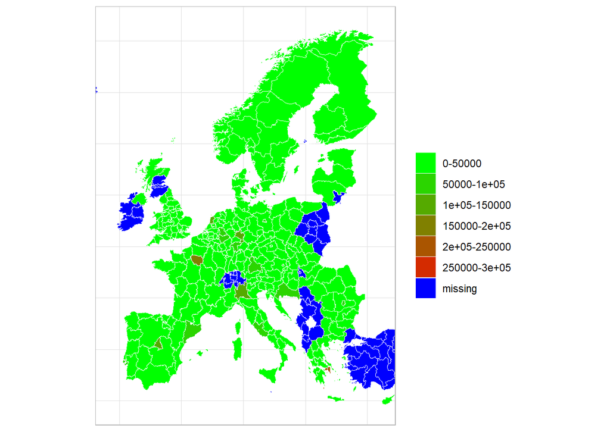

## The complete cases for the eurostat+eurobarometer dataset

The map below shows the total number of downloads per region, and the completeness of the second, richer, but smaller dataset.

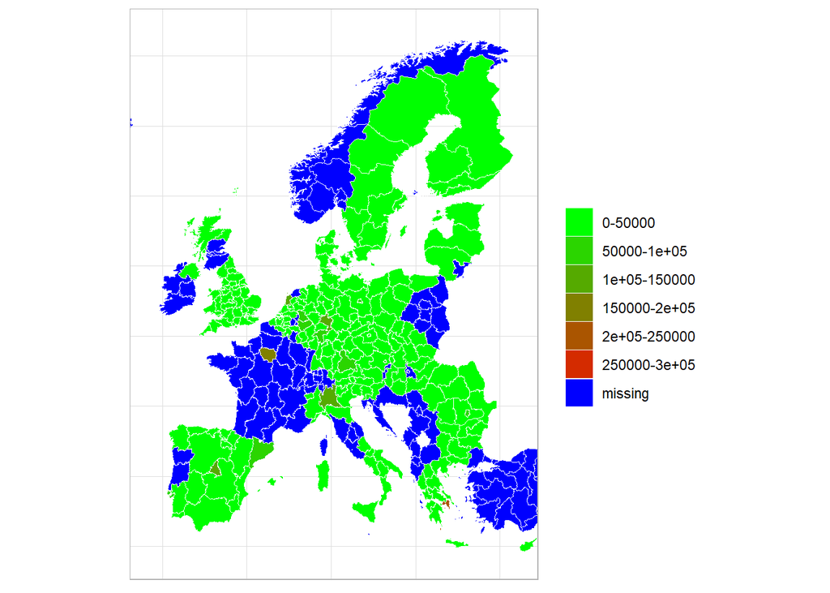

# Analysis

## Descriptives, and general concerns

The median number of downloads is 10k, the mean is higher, 18648. With some extreme outliers.

```r
summary(eurostat_complete_data$count)
```

```
##    Min. 1st Qu.  Median    Mean 3rd Qu.    Max.
##       0    4038   10095   18648   19477  274309
```

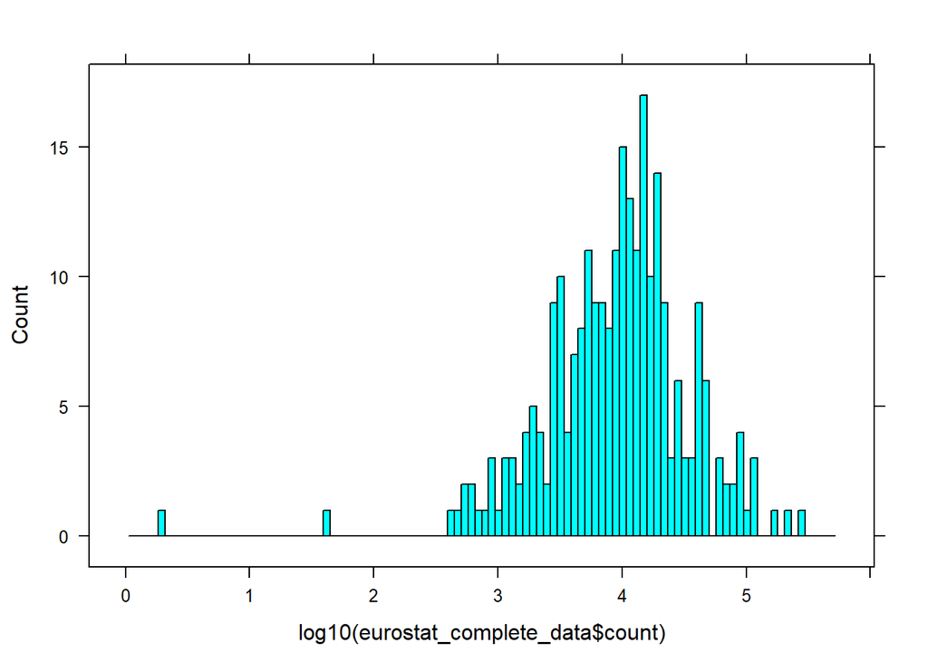

```r
histogram(log10(eurostat_complete_data$count),
          nint=100,
          type="count")
```

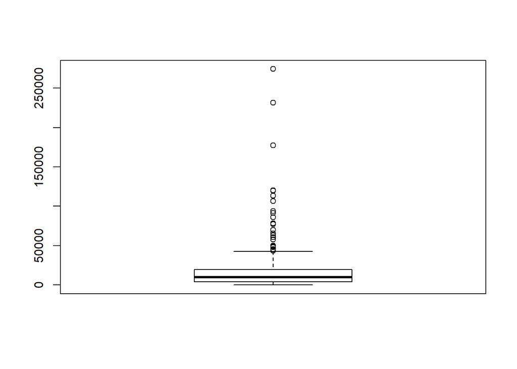

```r
boxplot(eurostat_complete_data$count)
```

Some of the other regions (see the maps above) are as expected, big, metropolitan regions, such as inner London, with large populations, and a strong concentration of knowledge-intensive activities. There are, however, exceptions to this rule, where regions without significant urban centers, or educational, research capacities demonstrate unusually high download volumes. We identified a number of possible reasons for these anomalies:

- there might be issues with the translation of IP addresses to geolocation. We used the MaxMind service to assign coordinates to IP addresses, and the accuracy of the service, may vary for different countries, or internet service providers. In this latter case, it is possible that lacking better information, whole IP ranges resolve to, for example, the HQ address of the provider, rather than to the approximate location of the user. This is a well-known issue in general, and a potential source of noise in our case as well.
- We did our best to identify Virtual Private Networks, TOR exit nodes, and other traffic sources, which may mask the true location of the downloader. However, such information may not always be available, therefore it is possible that we failed to identify traffic sources as VPNs. In such cases, we incorrectly associate substantial foreign traffic with a particular geographic location.
- Last, but not least, though we tried our best to identify bots and other automated traffic sources in the dataset. For example, we filtered repeated downloads from the same IP of the same book within a given time-window. However, it is possible that we did not identified all the automatic scraping, which does not represent human downloaders. In other parts of the dataset we have evidence for such automated, scraper-generated traffic, and on smaller scale, this might also produce unexpected outliers in the European dataset.

That being said, if we look at the degrees of correlation between or ultimate dependent variable, the number of downloads in a region, and other variables, we see strong correlations, especially with wealth (measured by GDP), the number of researchers, population, and knowledge intensive economic activities.

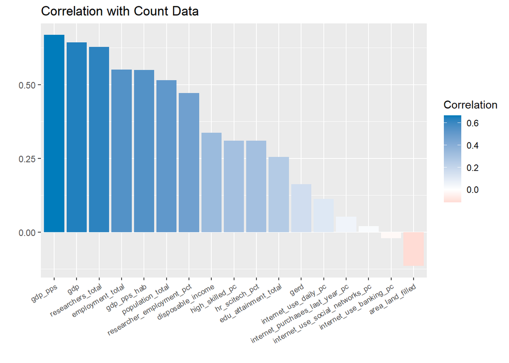

## Spatial auto-correlation

```
##
##  Monte-Carlo simulation of Moran I
##
## data:  moran_i_spdf %>% dplyr::select(count) %>% unlist() %>% as.numeric()
## weights: ww
## number of simulations + 1: 1000
##
## statistic = 0.042747, observed rank = 904, p-value = 0.096
## alternative hypothesis: greater
```

Similarly, running the same test for GDP adjusted by purchasing power standard, we see a very similar level of spatial autocorrelation.

[output not shown]

# Interaction with environmental variables

Next, we pursued the following modeling approach:

- first, we tried to test on the European dataset, the same hypothesis that we tested on the global data, namely that lower income regions compensate their infrastructural shortcomings by the more extensive use of piratical resources. We control for wealth, and knowledge intensive macro-economic variables, such as R7D sending, or the share of researchers in the active population. This would be a limited model in terms of independent variables, but which, in return, would allow us to include the most NUTS2 regions in the analysis.
- Second, we used alternative modeling techniques, such as random forest methods, to check if we could find additional variables which we could be included in our models. In this step we run this analysis on the narrower, but more larger EUORUSTAT dataset.
- Third, we add the EUROBAROMETER variables, at the expense of reducing somewhat the size of the dataset, and use the random forest approach to identify if there are important new explanatory variables among the newly added ones,
- lastly, we re-run any liner regression models if the random forest identified new variables.

## Hypothesis testing through simple linear regressions

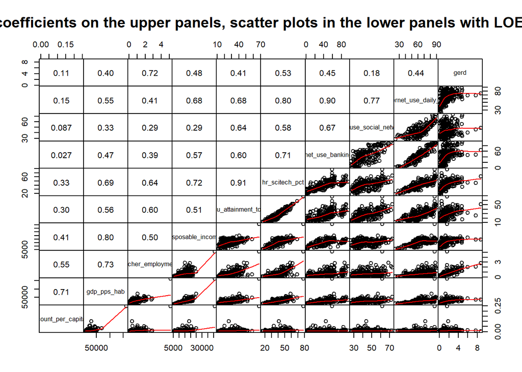

### per capital download models

```r
#poisson with scitech hr
percapita_plm1 <- glm (count_per_million ~
                 gdp_pps_hab +
                 researcher_employment_pct +
                 disposable_income +
                 edu_attainment_total +
                 hr_scitech_pct +
                 internet_use_banking_pc,
                 data = eurostat_complete_data,
                 family = poisson )


#poisson withoutr scitech hr
percapita_plm2 <- glm (count_per_million ~
                         gdp_pps_hab +
                         researcher_employment_pct +
                         disposable_income +
                         edu_attainment_total +
                         internet_use_banking_pc,

                        data = eurostat_complete_data,
                        family = poisson )

#Switch to log(gdp_pps)

percapita_plm3 <- glm (count_per_million ~
                         log(gdp_pps) +
                         researcher_employment_pct +
                         disposable_income +
                         edu_attainment_total +
                         internet_use_banking_pc,

                         data = eurostat_complete_data,
                         family = poisson )

#quasipoisson

percapita_qplm3 <- glm (count_per_million ~
                          log(gdp_pps) +
                          researcher_employment_pct +
                          internet_use_banking_pc,

                        data = eurostat_complete_data,
                        family = quasipoisson)

##try online shopping instead of banking
percapita_qplm4 <- glm (count_per_million ~
                          log(gdp_pps) +
                          researcher_employment_pct +
                          internet_purchases_last_year_pc,

                          data = eurostat_complete_data,
                          family = quasipoisson)

##try disposable income and edu level
percapita_qplm5 <- glm (count_per_million ~
                          log(gdp_pps) +
                          researcher_employment_pct +
                          internet_use_banking_pc +
                          log(disposable_income) ,

                        data =eurostat_complete_data,
                        family = quasipoisson)

percapita_qplm6 <- glm (count_per_million ~
                          log(gdp_pps) +
                          researcher_employment_pct +
                          internet_use_banking_pc +
                          gerd,

                        data =eurostat_complete_data,
                        family = quasipoisson)

percapita_qplm7 <- glm (count_per_million ~
                          log(gdp_pps) +
                          internet_use_banking_pc +
                          gerd,

                        data =eurostat_complete_data,
                        family = quasipoisson)
vif(percapita_qplm7)
```

```
##            log(gdp_pps) internet_use_banking_pc                    gerd
##                1.119251                1.229634                1.338946
```

```r
#summary(percapita_plm3)
#summary(percapita_qplm3)

export_summs(percapita_qplm3, percapita_qplm4, percapita_qplm5, percapita_qplm6,percapita_qplm7,
             digits=3,
             statistics = c("null.deviance", "deviance")
             )
```

[output not shown]

[output not shown]

|  | Model 1 | Model 2 | Model 3 | Model 4 | Model 5 |
| --- | --- | --- | --- | --- | --- |
| (Intercept) | 6.438 *** | 6.295 *** | -0.143 | 6.353 *** | 4.050 *** |
|  | (0.794) | (0.838) | (2.457) | (0.802) | (1.110) |
| log(gdp_pps) | 0.247 ** | 0.242 ** | 0.175 * | 0.258 ** | 0.490 *** |
|  | (0.077) | (0.081) | (0.075) | (0.078) | (0.105) |
| researcher_employment_pct | 0.697 *** | 0.683 *** | 0.570 *** | 0.702 *** |  |
|  | (0.057) | (0.063) | (0.068) | (0.055) |  |
| internet_use_banking_pc | -0.011 *** |  | -0.015 *** | -0.009 ** | -0.003 |
|  | (0.003) |  | (0.003) | (0.003) | (0.005) |
| internet_purchases_last_year_pc |  | -0.006 |  |  |  |
|  |  | (0.003) |  |  |  |
| log(disposable_income) |  |  | 0.792 ** |  |  |
|  |  |  | (0.280) |  |  |
| gerd |  |  |  | -0.070 | 0.059 |
|  |  |  |  | (0.053) | (0.076) |
| null.deviance | 2990524.371 | 2990524.371 | 2990524.371 | 2990524.371 | 2990524.371 |
| deviance | 1415805.433 | 1507337.393 | 1343129.996 | 1396838.896 | 2455507.137 |
| *** p < 0.001; ** p < 0.01; * p < 0.05. |  |  |  |  |  |

```r
#summary (percapita_qplm4)
```

The models offer the following findings:

- gdp is has a significant positive effect on the per capita downloads. wealthier regions download more.
- the per capita downloads grow with higher percentages of researchers in the labor pool. Researchers are a primary source of download traffic
- higher disposable income also leads to higher download activity.

These three effects point to different forms of structural demand effect. Economic activity, research activity drives demand for scientific literature. The disposable income points to an individual demand effect: higher disposable income does not lower piracy, but actually creates more demand.

- on the other hand, per capita downloads are moderated by better online skills. The negative effect of online banking use may point to a higher use of legal sources, such as online and offline purchases, but we should also consider that online proficiency provides the skills to hide the online traces of illegal activities via the use of VPNs and Tor browsing.

```
## Model has log-transformed predictors. Consider using `terms="gdp_pps [exp]"` to back-transform scale.
## Model has log-transformed predictors. Consider using `terms="gdp_pps [exp]"` to back-transform scale.
## Model has log-transformed predictors. Consider using `terms="gdp_pps [exp]"` to back-transform scale.
```

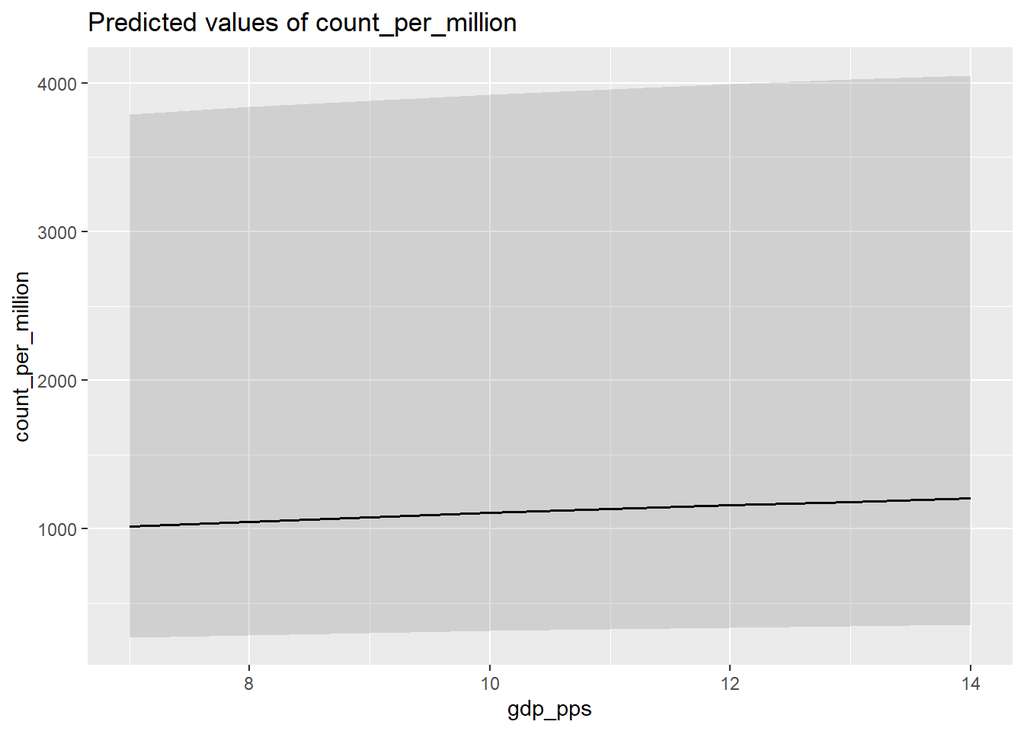

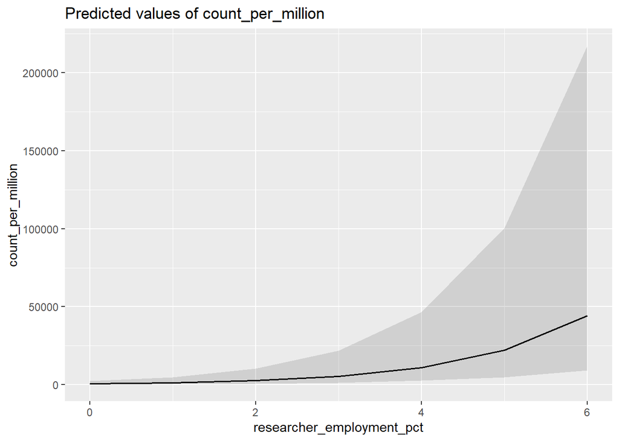

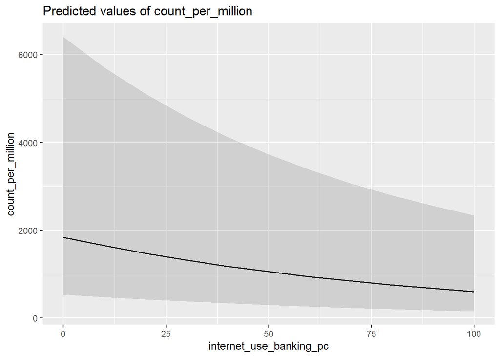

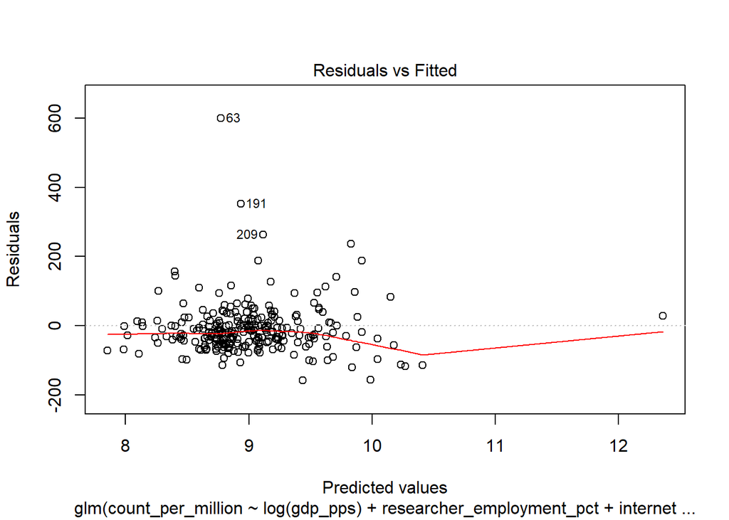

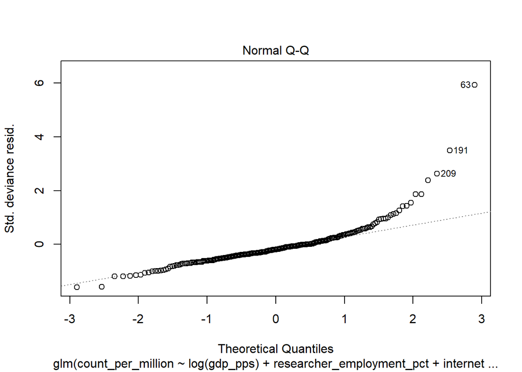

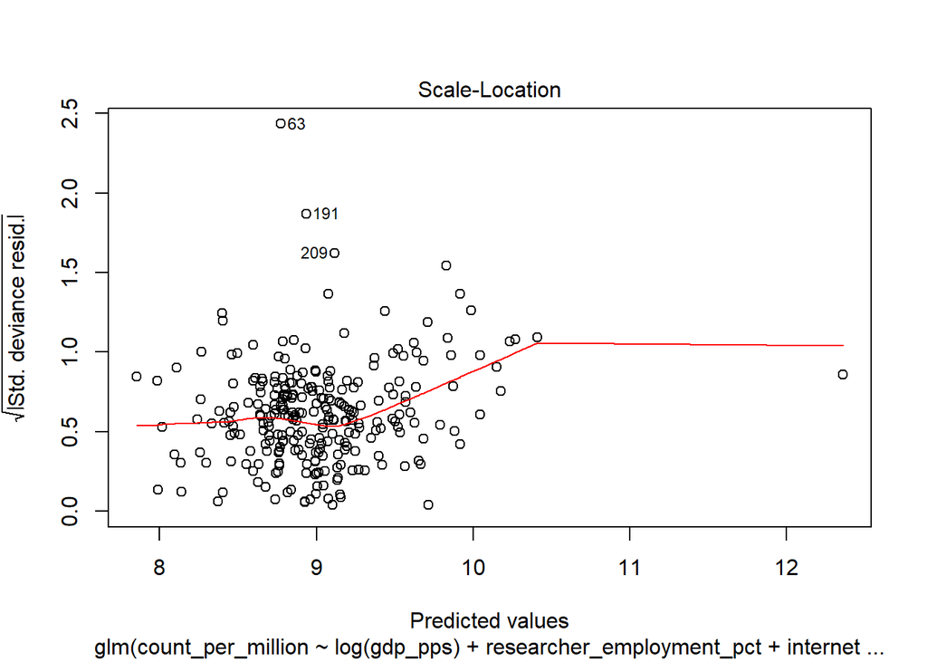

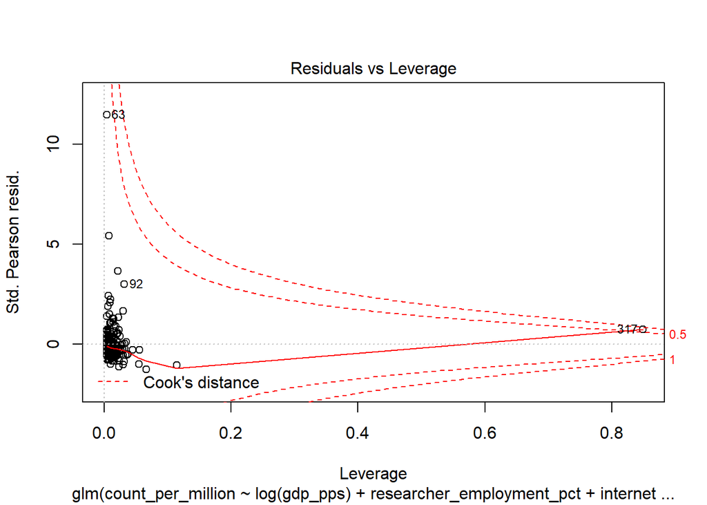

[output not shown]

[output cut: 246 more lines]

### per researcher download models

```r
#with scitech
perresearcher_plm2 <- glm (count_per_thousand_researchers ~
                             gdp_pps_hab  +
                             disposable_income +
                             edu_attainment_total + gerd +
                             internet_use_banking_pc+hr_scitech_pct,
                           data = eurostat_complete_data,
                           family = poisson )

#without
perresearcher_plm1 <- glm (count_per_thousand_researchers ~
                             log(gdp_pps)  +
                             log(disposable_income) +
                             edu_attainment_total + gerd +
                             internet_use_banking_pc,
                           data = eurostat_complete_data,
                           family = poisson )

#qpoisson model


perresearcher_qplm1 <- glm (count_per_thousand_researchers ~
                              log(gdp_pps)  + log(disposable_income) +
                              edu_attainment_total + gerd +
                              internet_use_banking_pc,
                            data = eurostat_complete_data,
                            family = quasipoisson )

perresearcher_qplm2 <- glm (count_per_thousand_researchers ~
                              log(gdp_pps)  + log(disposable_income) +
                              edu_attainment_total + gerd +
                              internet_purchases_last_year_pc,
                            data = eurostat_complete_data,
                            family = quasipoisson )

perresearcher_qplm3 <- glm (count_per_thousand_researchers ~
                              log(gdp_pps)*gerd,
                            data = eurostat_complete_data,
                            family = quasipoisson )

vif(perresearcher_qplm1)
```

```
##            log(gdp_pps)  log(disposable_income)    edu_attainment_total
##                1.346839                2.345741                1.644007
##                    gerd internet_use_banking_pc
##                1.625264                2.379288
```

```r
summary(perresearcher_qplm1)
```

```
##
## Call:
## glm(formula = count_per_thousand_researchers ~ log(gdp_pps) +
##     log(disposable_income) + edu_attainment_total + gerd + internet_use_banking_pc,
##     family = quasipoisson, data = eurostat_complete_data)
##
## Deviance Residuals:
##     Min       1Q   Median       3Q      Max
## -89.166  -22.578  -10.432    6.938  234.282
##
## Coefficients:
##                          Estimate Std. Error t value Pr(>|t|)
## (Intercept)              5.529855   2.239821   2.469  0.01420 *
## log(gdp_pps)             0.160907   0.070548   2.281  0.02337 *
## log(disposable_income)   0.148007   0.254805   0.581  0.56184
## edu_attainment_total     0.007557   0.007681   0.984  0.32613
## gerd                    -0.253286   0.079302  -3.194  0.00158 **
## internet_use_banking_pc -0.018276   0.004194  -4.358  1.9e-05 ***
## ---
## Signif. codes:  0 '***' 0.001 '**' 0.01 '*' 0.05 '.' 0.1 ' ' 1
##
## (Dispersion parameter for quasipoisson family taken to be 2078.842)
##
##     Null deviance: 495799  on 264  degrees of freedom
## Residual deviance: 362062  on 259  degrees of freedom
## AIC: NA
##
## Number of Fisher Scoring iterations: 5
```

```r
export_summs(perresearcher_qplm1, perresearcher_qplm2,perresearcher_qplm3,
             digits=3,
             statistics = c("null.deviance", "deviance")
             )
```

[output not shown]

[output not shown]

|  | Model 1 | Model 2 | Model 3 |
| --- | --- | --- | --- |
| (Intercept) | 5.530 * | 8.034 ** | 6.486 *** |
|  | (2.240) | (2.546) | (1.147) |
| log(gdp_pps) | 0.161 * | 0.174 * | 0.175 |
|  | (0.071) | (0.078) | (0.113) |
| log(disposable_income) | 0.148 | -0.143 |  |
|  | (0.255) | (0.291) |  |
| edu_attainment_total | 0.008 | -0.000 |  |
|  | (0.008) | (0.009) |  |
| gerd | -0.253 ** | -0.310 *** | -0.155 |
|  | (0.079) | (0.088) | (0.901) |
| internet_use_banking_pc | -0.018 *** |  |  |
|  | (0.004) |  |  |
| internet_purchases_last_year_pc |  | -0.006 |  |
|  |  | (0.004) |  |
| log(gdp_pps):gerd |  |  | -0.024 |
|  |  |  | (0.084) |
| null.deviance | 495798.787 | 495798.787 | 495798.787 |
| deviance | 362061.621 | 398536.668 | 414631.765 |
| *** p < 0.001; ** p < 0.01; * p < 0.05. |  |  |  |

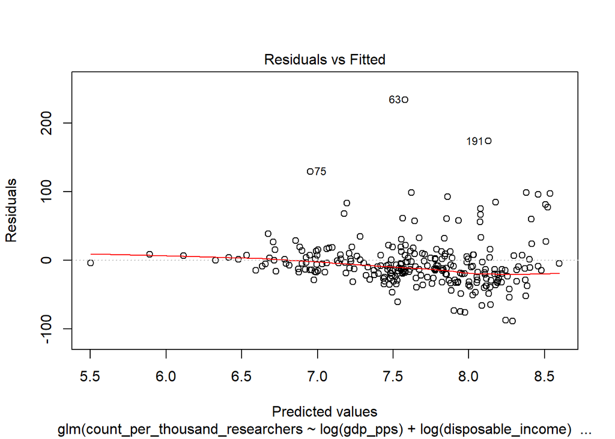

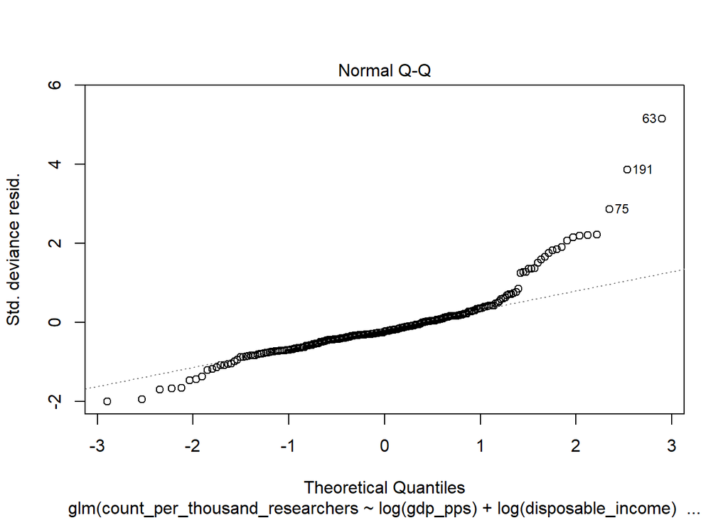

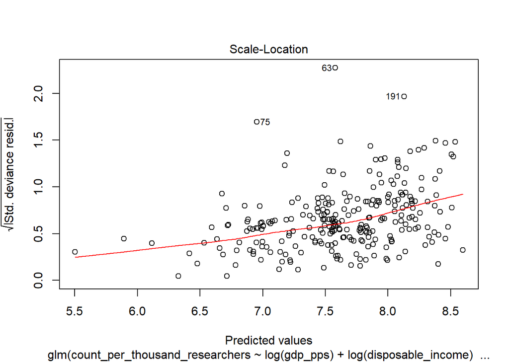

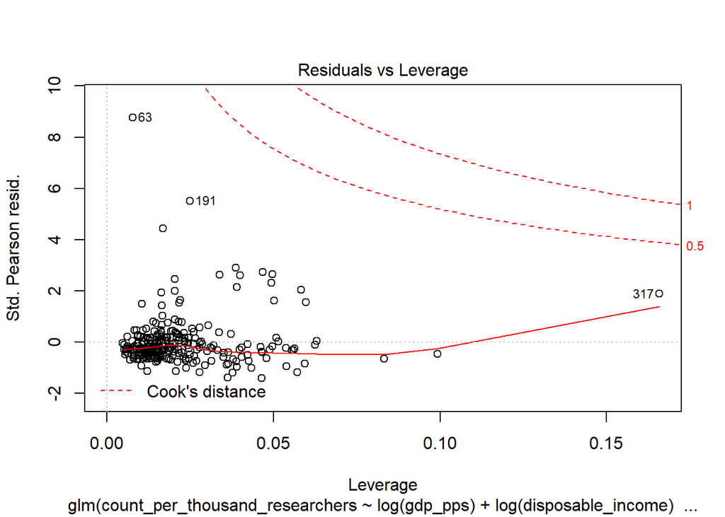

```r
plot(perresearcher_qplm1)
```

These results point to similar conclusions. the the per researcher download volume:

- still grows with wealth, but
- is moderated by the R&D expenditure, and internet proficiency.

Regions with more internet proficiency populations, and with higher R&D spending download less per researcher.

```
## Model has log-transformed predictors. Consider using `terms="gdp_pps [exp]"` to back-transform scale.
## Model has log-transformed predictors. Consider using `terms="gdp_pps [exp]"` to back-transform scale.
## Model has log-transformed predictors. Consider using `terms="gdp_pps [exp]"` to back-transform scale.
## Model has log-transformed predictors. Consider using `terms="gdp_pps [exp]"` to back-transform scale.
## Model has log-transformed predictors. Consider using `terms="gdp_pps [exp]"` to back-transform scale.
```

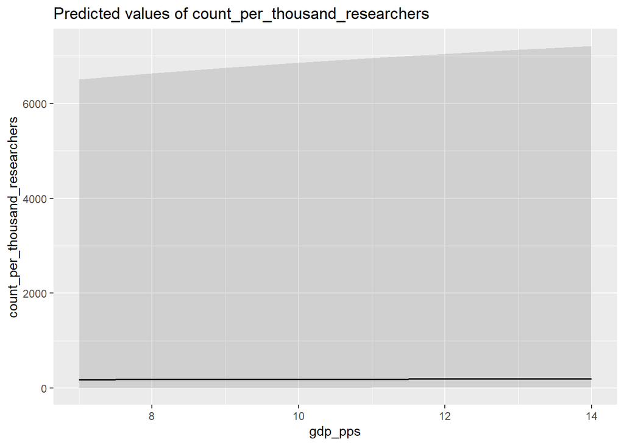

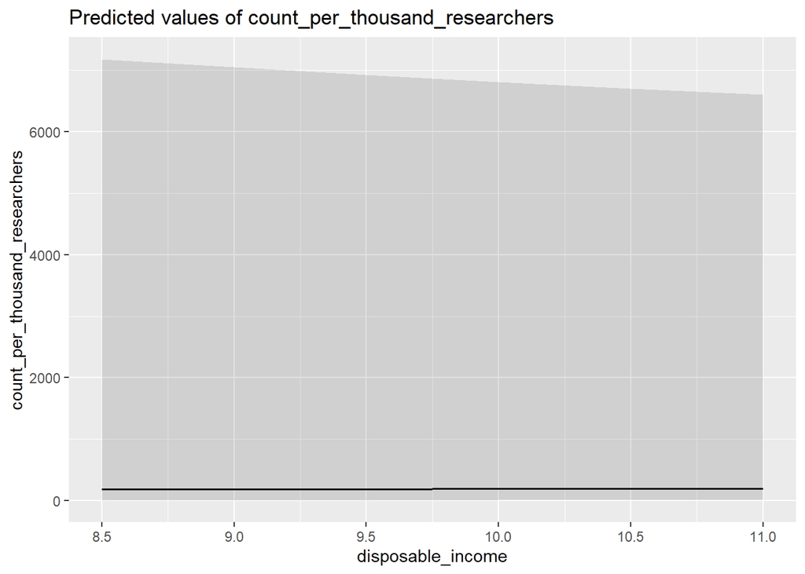

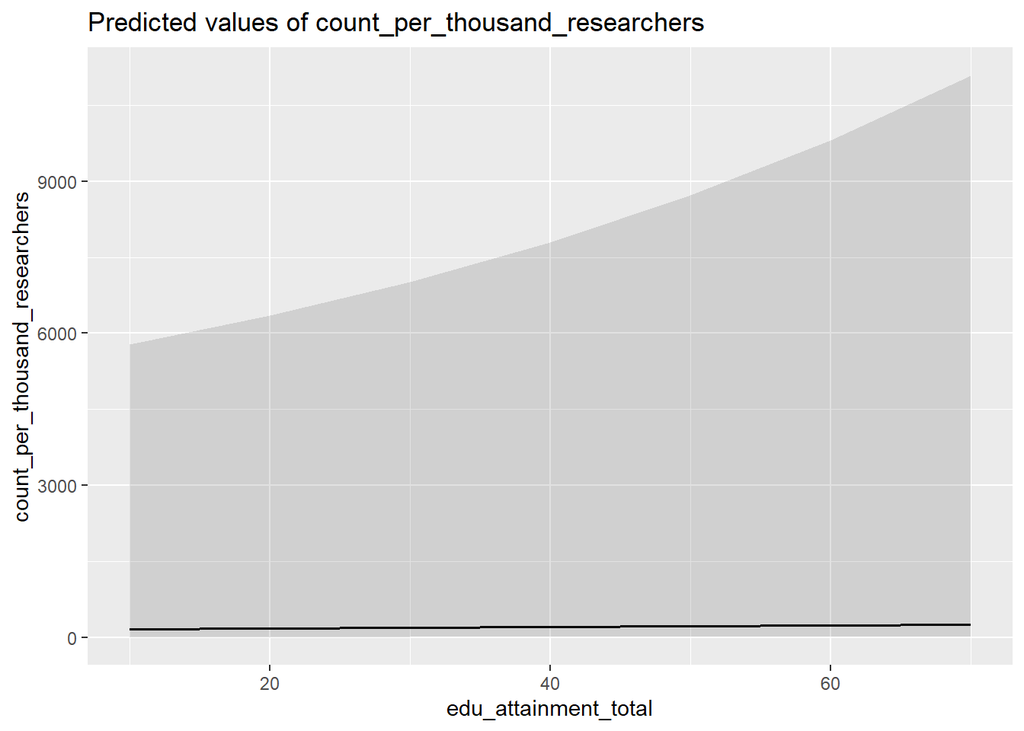

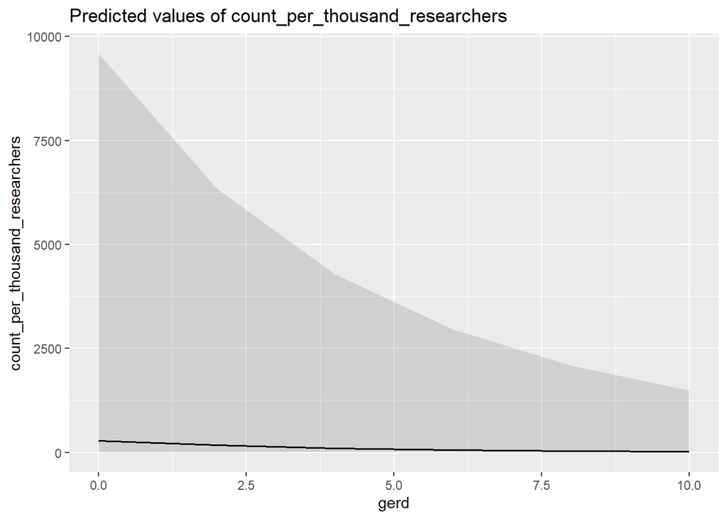

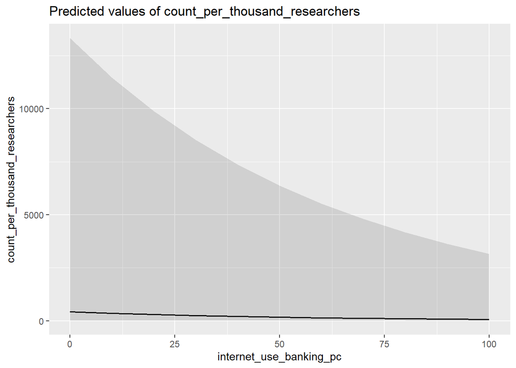

```r
plot_model(perresearcher_qplm1, type = "pred")
```

### Count Regression Models

```r
#count without R&D
count_plm2 <- glm (count ~ log(gdp_pps) +  researcher_employment_pct +
                 disposable_income +
                 edu_attainment_total +
                 internet_use_banking_pc,
                 data = eurostat_complete_data, poisson )

#with R&D
count_plm3 <- glm (count ~ log(gdp_pps) +  researcher_employment_pct +
                 disposable_income +
                 edu_attainment_total +
                 internet_use_banking_pc +
                  gerd
                , data = eurostat_complete_data, poisson )

count_plm4 <- glm (count ~ log(gdp_pps) +
                    researcher_employment_pct +
                    disposable_income +
                    edu_attainment_total +
                    internet_use_banking_pc +
                    gerd+
                    internet_purchases_last_year_pc
                    , data = eurostat_complete_data, poisson )

vif(count_plm4)
```

```
##                    log(gdp_pps)       researcher_employment_pct
##                        1.479542                        7.264413
##               disposable_income            edu_attainment_total
##                        5.850430                        4.948335
##         internet_use_banking_pc                            gerd
##                        4.042030                        1.767706
## internet_purchases_last_year_pc
##                        6.105920
```

```r
summary (count_plm4)
```

```
##
## Call:
## glm(formula = count ~ log(gdp_pps) + researcher_employment_pct +
##     disposable_income + edu_attainment_total + internet_use_banking_pc +
##     gerd + internet_purchases_last_year_pc, family = poisson,
##     data = eurostat_complete_data)
##
## Deviance Residuals:
##     Min       1Q   Median       3Q      Max
## -359.24   -50.92   -24.84    18.49   600.08
##
## Coefficients:
##                                   Estimate Std. Error z value Pr(>|z|)
## (Intercept)                     -3.669e-01  5.997e-03  -61.18   <2e-16 ***
## log(gdp_pps)                     9.834e-01  5.882e-04 1671.93   <2e-16 ***
## researcher_employment_pct        4.190e-01  1.056e-03  396.82   <2e-16 ***
## disposable_income               -2.145e-05  1.545e-07 -138.82   <2e-16 ***
## edu_attainment_total             1.004e-02  7.646e-05  131.25   <2e-16 ***
## internet_use_banking_pc         -2.297e-02  4.640e-05 -495.06   <2e-16 ***
## gerd                            -4.835e-02  4.640e-04 -104.20   <2e-16 ***
## internet_purchases_last_year_pc  6.351e-03  4.688e-05  135.47   <2e-16 ***
## ---
## Signif. codes:  0 '***' 0.001 '**' 0.01 '*' 0.05 '.' 0.1 ' ' 1
##
## (Dispersion parameter for poisson family taken to be 1)
##
##     Null deviance: 7192467  on 264  degrees of freedom
## Residual deviance: 1966657  on 257  degrees of freedom
## AIC: 1969514
##
## Number of Fisher Scoring iterations: 5
```

```r
summary (count_plm3)
```

```
##
## Call:
## glm(formula = count ~ log(gdp_pps) + researcher_employment_pct +
##     disposable_income + edu_attainment_total + internet_use_banking_pc +
##     gerd, family = poisson, data = eurostat_complete_data)
##
## Deviance Residuals:
##     Min       1Q   Median       3Q      Max
## -361.15   -49.67   -23.02    18.05   610.94
##
## Coefficients:
##                             Estimate Std. Error z value Pr(>|z|)
## (Intercept)               -2.742e-01  5.927e-03  -46.27   <2e-16 ***
## log(gdp_pps)               9.632e-01  5.643e-04 1706.91   <2e-16 ***
## researcher_employment_pct  3.657e-01  9.788e-04  373.67   <2e-16 ***
## disposable_income         -1.130e-05  1.352e-07  -83.56   <2e-16 ***
## edu_attainment_total       1.361e-02  7.089e-05  192.04   <2e-16 ***
## internet_use_banking_pc   -1.872e-02  3.352e-05 -558.44   <2e-16 ***
## gerd                      -2.595e-02  4.324e-04  -60.03   <2e-16 ***
## ---
## Signif. codes:  0 '***' 0.001 '**' 0.01 '*' 0.05 '.' 0.1 ' ' 1
##
## (Dispersion parameter for poisson family taken to be 1)
##
##     Null deviance: 7192467  on 264  degrees of freedom
## Residual deviance: 1985062  on 258  degrees of freedom
## AIC: 1987918
##
## Number of Fisher Scoring iterations: 5
```

```r
#qpoisson
count_qplm2 <- glm (count ~ log(gdp_pps) +  researcher_employment_pct +
                 log(disposable_income) +
                 edu_attainment_total +
                 internet_use_banking_pc,
                 data = eurostat_complete_data, quasipoisson)

count_qplm3<- glm (count ~ log(gdp_pps) +  researcher_employment_pct +
                 log(disposable_income) +
                 edu_attainment_total +
                 internet_use_banking_pc +
                gerd,
                data = eurostat_complete_data, quasipoisson )

#is there multicollinearity? yes.
vif(count_qplm3)
```

```
##              log(gdp_pps) researcher_employment_pct    log(disposable_income)
##                  1.452575                  4.324325                  3.176083
##      edu_attainment_total   internet_use_banking_pc                      gerd
##                  4.304273                  2.274701                  1.479112
```

```r
count_qplm3a<- glm (count ~ log(gdp_pps) +
                 log(disposable_income) +
                 edu_attainment_total +
                 internet_use_banking_pc +
                gerd,
                data = eurostat_complete_data, quasipoisson )

count_qplm3b<- glm (count ~ log(gdp_pps) +
                 log(disposable_income) +
                 internet_use_banking_pc +
                gerd,
                data = eurostat_complete_data, quasipoisson )

# is gerd sinificant if we remove researcher pct? no. education attainment?
summary(count_qplm3a)
```

```
##
## Call:
## glm(formula = count ~ log(gdp_pps) + log(disposable_income) +
##     edu_attainment_total + internet_use_banking_pc + gerd, family = quasipoisson,
##     data = eurostat_complete_data)
##
## Deviance Residuals:
##     Min       1Q   Median       3Q      Max
## -355.13   -54.44   -22.30    17.23   575.64
##
## Coefficients:
##                          Estimate Std. Error t value Pr(>|t|)
## (Intercept)             -3.098086   1.974263  -1.569    0.118
## log(gdp_pps)             0.963964   0.063842  15.099  < 2e-16 ***
## log(disposable_income)   0.261247   0.235443   1.110    0.268
## edu_attainment_total     0.032279   0.005526   5.841 1.55e-08 ***
## internet_use_banking_pc -0.023900   0.003638  -6.569 2.77e-10 ***
## gerd                     0.028054   0.044957   0.624    0.533
## ---
## Signif. codes:  0 '***' 0.001 '**' 0.01 '*' 0.05 '.' 0.1 ' ' 1
##
## (Dispersion parameter for quasipoisson family taken to be 12110.63)
##
##     Null deviance: 7192467  on 264  degrees of freedom
## Residual deviance: 2155840  on 259  degrees of freedom
## AIC: NA
##
## Number of Fisher Scoring iterations: 5
```

```r
count_qplm4 <- glm (count ~ log(gdp_pps) +
                    researcher_employment_pct +
                    log(disposable_income) +
                    edu_attainment_total +
                    gerd +
                    internet_purchases_last_year_pc,
                    data = eurostat_complete_data, quasipoisson )

export_summs(count_qplm2,count_qplm3,count_qplm4, digits=10, statistics = "all")
```

[output not shown]

|  | Model 1 | Model 2 | Model 3 |
| --- | --- | --- | --- |
| (Intercept) | 0.6211211100 | 0.5730664396 | 0.9031886983 |
|  | (2.1132612052) | (2.1172749655) | (2.4913320060) |
| log(gdp_pps) | 0.9551262540 *** | 0.9590985572 *** | 0.9637326812 *** |
|  | (0.0632768252) | (0.0640742590) | (0.0702790552) |
| researcher_employment_pct | 0.3181504930 *** | 0.3271627382 *** | 0.4061957483 *** |
|  | (0.0863298463) | (0.0890344766) | (0.1010201684) |
| log(disposable_income) | -0.1028660123 | -0.0997598068 | -0.1448320037 |
|  | (0.2460385841) | (0.2461695466) | (0.2927885566) |
| edu_attainment_total | 0.0147511373 * | 0.0138489820 | 0.0047686346 |
|  | (0.0074391023) | (0.0077696817) | (0.0089738727) |
| internet_use_banking_pc | -0.0195794874 *** | -0.0189299950 *** |  |
|  | (0.0034621068) | (0.0038077620) |  |
| gerd |  | -0.0190133191 | -0.0679065142 |
|  |  | (0.0466327558) | (0.0533571307) |
| internet_purchases_last_year_pc |  |  | -0.0096134646 * |
|  |  |  | (0.0041407114) |
| nobs | 265 | 265 | 265 |
| null.deviance | 7192467.3824574202 | 7192467.3824574202 | 7192467.3824574202 |
| df.null | 264.0000000000 | 264.0000000000 | 264.0000000000 |
| logLik |  |  |  |
| AIC |  |  |  |
| BIC |  |  |  |
| deviance | 1992084.2207974601 | 1990052.0420572299 | 2228815.7826950401 |
| df.residual | 259.0000000000 | 258.0000000000 | 258.0000000000 |
| pseudo.r.squared | 1.0000000000 | 1.0000000000 | 1.0000000000 |
| pseudo.r.squared.mcfadden | 0.7227462984 | 0.7230287294 | 0.6898454804 |
| *** p < 0.001; ** p < 0.01; * p < 0.05. |  |  |  |

[output not shown]

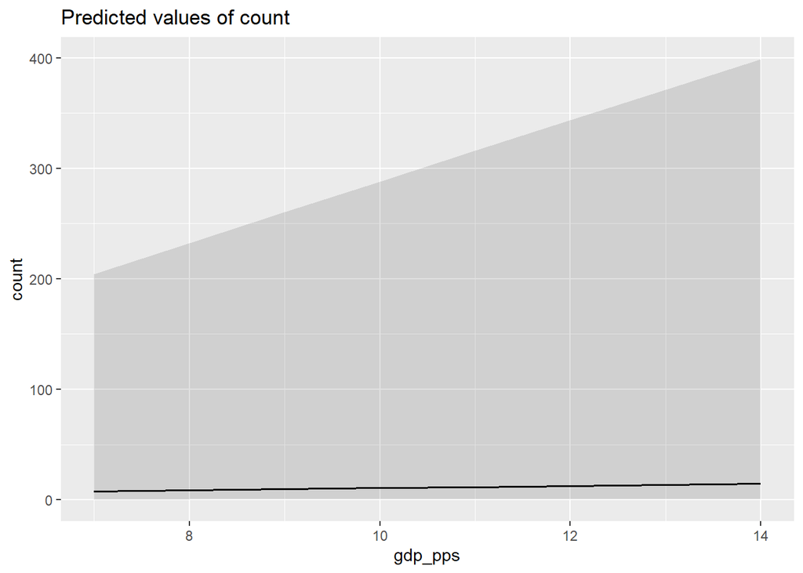

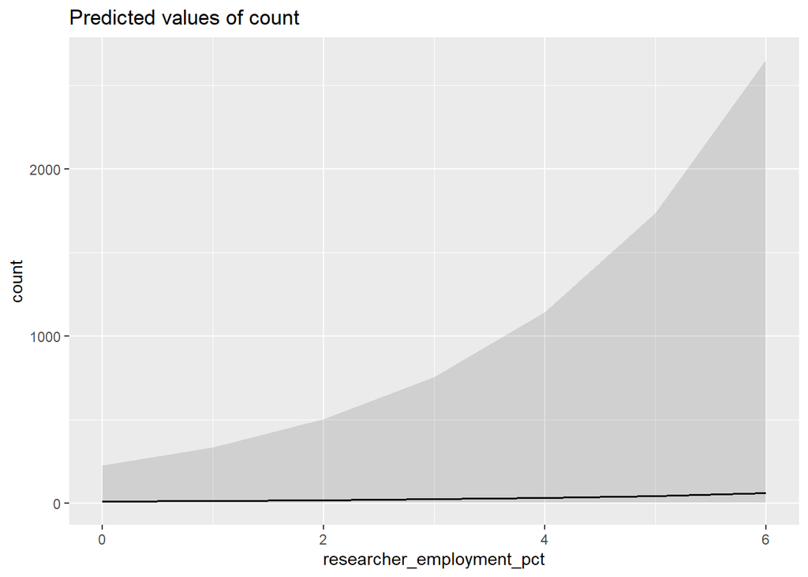

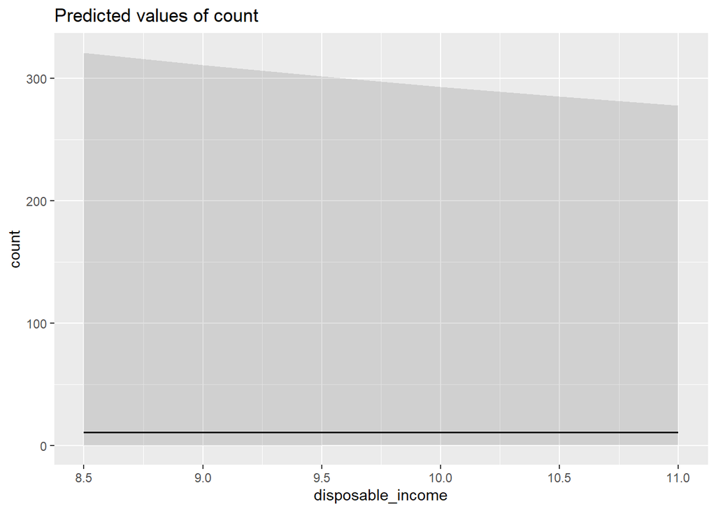

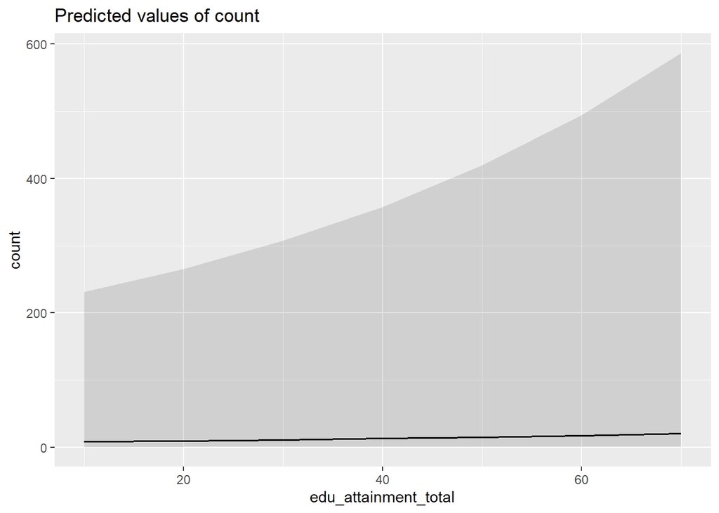

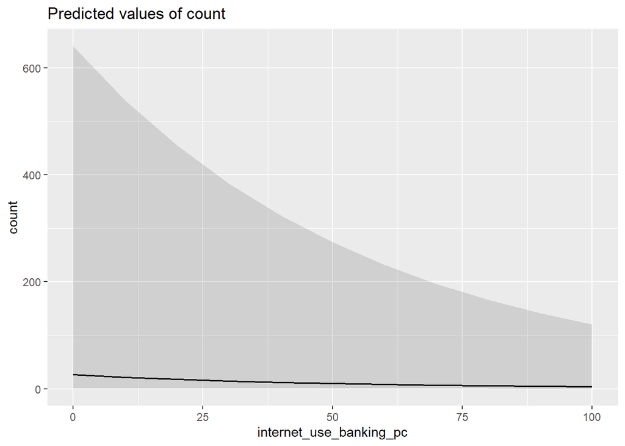

## Comparing the Three Models

If we compare the three models (per capita, per researcher, and absolute download counts, all modeled as quasipoisson), we find that consistent results. wealth, researcher employment has a positive effect, internet proficiency has a negative effect. In the model per researcher model we see that higher R&D expenditure can lower download counts.

[output not shown]

|  | percapita | perresearcher | count |
| --- | --- | --- | --- |
| (Intercept) | 6.4383579762 *** | 5.5298545753 * | 0.6211211100 |
|  | (0.7937306511) | (2.2398209742) | (2.1132612052) |
| log(gdp_pps) | 0.2465563796 ** | 0.1609069163 * | 0.9551262540 *** |
|  | (0.0769748083) | (0.0705484186) | (0.0632768252) |
| researcher_employment_pct | 0.6966753816 *** |  | 0.3181504930 *** |
|  | (0.0565692560) |  | (0.0863298463) |
| internet_use_banking_pc | -0.0111376705 *** | -0.0182764133 *** | -0.0195794874 *** |
|  | (0.0032270824) | (0.0041940523) | (0.0034621068) |
| log(disposable_income) |  | 0.1480069549 | -0.1028660123 |
|  |  | (0.2548048700) | (0.2460385841) |
| edu_attainment_total |  | 0.0075568225 | 0.0147511373 * |
|  |  | (0.0076812247) | (0.0074391023) |
| gerd |  | -0.2532864784 ** |  |
|  |  | (0.0793017980) |  |
| nobs | 265 | 265 | 265 |
| null.deviance | 2990524.3713359898 | 495798.7867977770 | 7192467.3824574202 |
| df.null | 264.0000000000 | 264.0000000000 | 264.0000000000 |
| logLik |  |  |  |
| AIC |  |  |  |
| BIC |  |  |  |
| deviance | 1415805.4334292000 | 362061.6209839690 | 1992084.2207974601 |
| df.residual | 261.0000000000 | 259.0000000000 | 259.0000000000 |
| pseudo.r.squared | 1.0000000000 | 1.0000000000 | 1.0000000000 |
| pseudo.r.squared.mcfadden | 0.5260853485 | 0.2684410421 | 0.7227462984 |
| *** p < 0.001; ** p < 0.01; * p < 0.05. |  |  |  |

To check the robustness of these models, we also did simple linear regression for all 3 dependent variables. They do not yield different results from the quasipoisson models, but their error terms are much uglier.

Regions with higher gdp and higher researcher share in the workforce download more, while higher online proficiency lowers download numbers, probably due to the positive effects of e-commerce, and the negative effects of better hiding.

## interaction models

Finally, we check the interaction of wealth (GDP_PPS) and researcher employment with a simple interaction model.

### simple count variable, GDP and researcher share

```r
interaction_qplm1<- glm (count  ~ gdp_pps * researcher_employment_pct,
                         data = eurostat_complete_data,
                         family = quasipoisson )

summary (interaction_qplm1)
```

```
##
## Call:
## glm(formula = count ~ gdp_pps * researcher_employment_pct, family = quasipoisson,
##     data = eurostat_complete_data)
##
## Deviance Residuals:
##     Min       1Q   Median       3Q      Max
## -345.53   -84.90   -37.05    17.52   765.65
##
## Coefficients:
##                                     Estimate Std. Error t value Pr(>|t|)
## (Intercept)                        8.546e+00  1.588e-01  53.830  < 2e-16 ***
## gdp_pps                            1.051e-05  1.279e-06   8.216 9.87e-15 ***
## researcher_employment_pct          9.183e-01  1.159e-01   7.926 6.60e-14 ***
## gdp_pps:researcher_employment_pct -3.479e-06  7.195e-07  -4.836 2.27e-06 ***
## ---
## Signif. codes:  0 '***' 0.001 '**' 0.01 '*' 0.05 '.' 0.1 ' ' 1
##
## (Dispersion parameter for quasipoisson family taken to be 21449.96)
##
##     Null deviance: 7192467  on 264  degrees of freedom
## Residual deviance: 3556374  on 261  degrees of freedom
## AIC: NA
##
## Number of Fisher Scoring iterations: 5
```

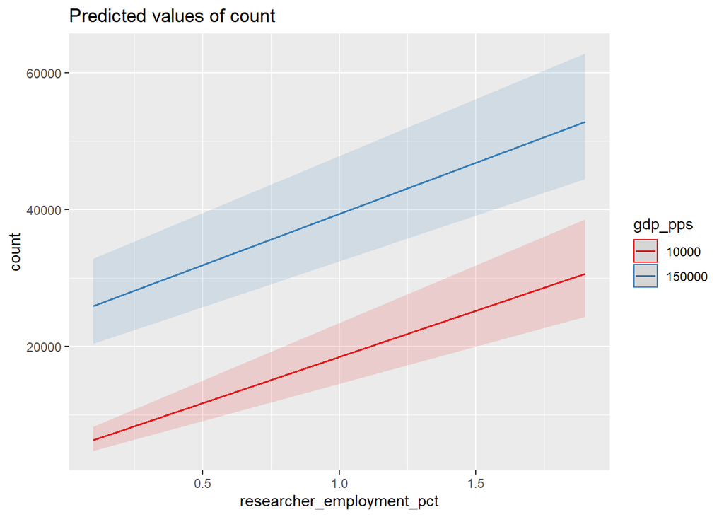

```r
plot_model(interaction_qplm1,
           type = "eff", terms=c("researcher_employment_pct[0.1,1.9]",
                                 "gdp_pps [10000,150000]"))
```

```r
#per capita model does not yield meaningful interaction. only researcher share significant
interaction_qplm2 <- glm (count_per_million  ~
                           gdp_pps * researcher_employment_pct,
                         data = eurostat_complete_data,
                         family = quasipoisson )
summary (interaction_qplm2)
```

```
##
## Call:
## glm(formula = count_per_million ~ gdp_pps * researcher_employment_pct,
##     family = quasipoisson, data = eurostat_complete_data)
##
## Deviance Residuals:
##     Min       1Q   Median       3Q      Max
## -201.32   -54.51   -18.54    18.18   596.39
##
## Coefficients:
##                                    Estimate Std. Error t value Pr(>|t|)
## (Intercept)                       8.540e+00  1.567e-01  54.492  < 2e-16 ***
## gdp_pps                           5.049e-07  1.654e-06   0.305    0.760
## researcher_employment_pct         6.444e-01  1.276e-01   5.052 8.23e-07 ***
## gdp_pps:researcher_employment_pct 3.566e-07  8.692e-07   0.410    0.682
## ---
## Signif. codes:  0 '***' 0.001 '**' 0.01 '*' 0.05 '.' 0.1 ' ' 1
##
## (Dispersion parameter for quasipoisson family taken to be 11203.89)
##
##     Null deviance: 2990524  on 264  degrees of freedom
## Residual deviance: 1602050  on 261  degrees of freedom
## AIC: NA
##
## Number of Fisher Scoring iterations: 5
```

```r
#per researcher models yield little.  gdp is not relevant
interaction_qplm3 <- glm (count_per_thousand_researchers ~
                            gdp_pps * internet_use_banking_pc,
                          data = eurostat_complete_data,
                          family = quasipoisson )

summary (interaction_qplm3)
```

```
##
## Call:
## glm(formula = count_per_thousand_researchers ~ gdp_pps * internet_use_banking_pc,
##     family = quasipoisson, data = eurostat_complete_data)
##
## Deviance Residuals:
##     Min       1Q   Median       3Q      Max
## -84.632  -23.533  -11.553    5.234  228.824
##
## Coefficients:
##                                   Estimate Std. Error t value Pr(>|t|)
## (Intercept)                      8.512e+00  1.452e-01  58.603  < 2e-16 ***
## gdp_pps                         -7.355e-07  2.909e-06  -0.253    0.801
## internet_use_banking_pc         -1.921e-02  3.439e-03  -5.586 5.83e-08 ***
## gdp_pps:internet_use_banking_pc  1.898e-08  5.846e-08   0.325    0.746
## ---
## Signif. codes:  0 '***' 0.001 '**' 0.01 '*' 0.05 '.' 0.1 ' ' 1
##
## (Dispersion parameter for quasipoisson family taken to be 2177.066)
##
##     Null deviance: 495799  on 264  degrees of freedom
## Residual deviance: 392699  on 261  degrees of freedom
## AIC: NA
##
## Number of Fisher Scoring iterations: 5
```

Other interaction models with per capita and per researcher dependent variables, and wealth and researcher employment and online proficiency do not yield significant results.

# Inductive models

We took a first look at this data with two methods. First, we created all possible linear regression equations and two-variable multiple linear regression between the count data and the socio-economic variables. We also used the random forest algorithm to rank the importance of socio-economic environmental variables in explaining the difference in the level of book piracy. The logic of the two approaches is similar. We use a well-defined searching algorithm to find a relationship between the levels of socio-economic environmental variables and download count numbers. We did the inductive approach twice: first on the larger, but narrower dataset used so far, and second for a smaller dataset which includes new variables from the EUROBAROMETER dataset.

## Linear regression models

To understand the interaction of environmental variables and count data, we created all possible linear regressions ‘explaining’ the variability of count per capita data in the following steps:

- We created the initial linear regression
- We checked for outliers, and removed them
- Re-run the regression model, and selected those whose coefficients were significant on 1.96 level
- We ordered the remaining 38 models by adjusted R squares.

The following table shows the results of this approach for the smaller, dataset with additional Eurobarometer variables. We get very results consistent with these, if we run the analysis on the larger dataset.

| rowname | model | r.squared | adj.r.squared | (Intercept) | names | values |
| --- | --- | --- | --- | --- | --- | --- |
| 21 | gdp_pps_hab+internet_use_banking_pc | 0.156 | 0.15 | -14.8 | gdp_pps_hab | 0.0012 |
| 21 | gdp_pps_hab+internet_use_banking_pc | 0.156 | 0.15 | -14.8 | internet_use_banking_pc | -0.227 |
| 39 | internet_use_banking_pc+gdp_pps_hab | 0.156 | 0.15 | -14.8 | gdp_pps_hab | 0.0012 |
| 39 | internet_use_banking_pc+gdp_pps_hab | 0.156 | 0.15 | -14.8 | internet_use_banking_pc | -0.227 |
| 20 | gdp_pps_hab+internet_purchases_last_year_pc | 0.144 | 0.138 | -14.6 | gdp_pps_hab | 0.00113 |
| 20 | gdp_pps_hab+internet_purchases_last_year_pc | 0.144 | 0.138 | -14.6 | internet_purchases_last_year_pc | -0.169 |
| 36 | internet_purchases_last_year_pc+gdp_pps_hab | 0.144 | 0.138 | -14.6 | gdp_pps_hab | 0.00113 |
| 36 | internet_purchases_last_year_pc+gdp_pps_hab | 0.144 | 0.138 | -14.6 | internet_purchases_last_year_pc | -0.169 |
| 23 | high_skilled_pc+erobarometer_79_2_is_visit_public_library | 0.112 | 0.104 | -26.7 | high_skilled_pc | 1.08 |
| 23 | high_skilled_pc+erobarometer_79_2_is_visit_public_library | 0.112 | 0.104 | -26.7 | erobarometer_79_2_is_visit_public_library | -28.6 |
| 30 | hr_scitech_pct+erobarometer_79_2_is_visit_public_library | 0.112 | 0.104 | -26.7 | hr_scitech_pct | 1.08 |
| 30 | hr_scitech_pct+erobarometer_79_2_is_visit_public_library | 0.112 | 0.104 | -26.7 | erobarometer_79_2_is_visit_public_library | -28.6 |
| 10 | erobarometer_79_2_is_visit_public_library+high_skilled_pc | 0.112 | 0.104 | -26.7 | high_skilled_pc | 1.08 |
| 10 | erobarometer_79_2_is_visit_public_library+high_skilled_pc | 0.112 | 0.104 | -26.7 | erobarometer_79_2_is_visit_public_library | -28.6 |
| 11 | erobarometer_79_2_is_visit_public_library+hr_scitech_pct | 0.112 | 0.104 | -26.7 | hr_scitech_pct | 1.08 |
| 11 | erobarometer_79_2_is_visit_public_library+hr_scitech_pct | 0.112 | 0.104 | -26.7 | erobarometer_79_2_is_visit_public_library | -28.6 |
| 26 | high_skilled_pc+internet_use_banking_pc | 0.109 | 0.103 | -28.6 | high_skilled_pc | 1.17 |
| 26 | high_skilled_pc+internet_use_banking_pc | 0.109 | 0.103 | -28.6 | internet_use_banking_pc | -0.279 |
| 33 | hr_scitech_pct+internet_use_banking_pc | 0.109 | 0.103 | -28.6 | hr_scitech_pct | 1.17 |
| 33 | hr_scitech_pct+internet_use_banking_pc | 0.109 | 0.103 | -28.6 | internet_use_banking_pc | -0.279 |
| 40 | internet_use_banking_pc+high_skilled_pc | 0.109 | 0.103 | -28.6 | high_skilled_pc | 1.17 |
| 40 | internet_use_banking_pc+high_skilled_pc | 0.109 | 0.103 | -28.6 | internet_use_banking_pc | -0.279 |
| 41 | internet_use_banking_pc+hr_scitech_pct | 0.109 | 0.103 | -28.6 | hr_scitech_pct | 1.17 |
| 41 | internet_use_banking_pc+hr_scitech_pct | 0.109 | 0.103 | -28.6 | internet_use_banking_pc | -0.279 |
| 37 | internet_purchases_last_year_pc+high_skilled_pc | 0.105 | 0.099 | -28.9 | high_skilled_pc | 1.21 |
| 37 | internet_purchases_last_year_pc+high_skilled_pc | 0.105 | 0.099 | -28.9 | internet_purchases_last_year_pc | -0.277 |
| 38 | internet_purchases_last_year_pc+hr_scitech_pct | 0.105 | 0.099 | -28.9 | hr_scitech_pct | 1.21 |
| 38 | internet_purchases_last_year_pc+hr_scitech_pct | 0.105 | 0.099 | -28.9 | internet_purchases_last_year_pc | -0.277 |
| 25 | high_skilled_pc+internet_purchases_last_year_pc | 0.105 | 0.099 | -28.9 | high_skilled_pc | 1.21 |
| 25 | high_skilled_pc+internet_purchases_last_year_pc | 0.105 | 0.099 | -28.9 | internet_purchases_last_year_pc | -0.277 |

[output cut: 64 more lines]

This approach shows results which are consistent with the deductive models. Wealth, the percentage of knowledge workers in the workforce has positive effects, online proficiency (in all forms) has a negative effect. What is new are the emergence of tow of the new EUROBAROMETER variables: the share of population who visited a public library at least once in the last 12 months (with a negative sign), and the percentage of students in he population (with a positive one). It is equally informative that neither the open science attitudinal variable (weighted sum of yes answer options to the QD 17 Do you think that the results of publicly funded research should be made available online free of charge?), nor the library inadequacy variable (a weighted sum of the responses that chose from the question block QB2 why you haven’t Visited a public library or haven’t done it more often in the last 12 months? … answered with the option: Limited or poor quality of this activity in the place where you live.) emerged as significant variables. We should note, that in this latter case, the number of respondents is rather low and this is not a very reliable statistic on regional level.

## Random forest models

In the following we created three sets of analysis: one that uses count per researcher as the dependent variable, One that uses download per capita as download variable, and one that uses raw count as a dependent variable. The reason for that is that if i use dl/researcher variable as dependent, I may not be able to capture and explain the downloads that possibly come from non-researchers, while if I use dl/capita, then i may find independent variables that account for the professional (researcher downloads) and others that are more characteristic for no-professionals. In the next step we scaled the variables to unit variance, so that they have equal weight in the variable selection process.

## count per capita -without eurobarometer

| variable | IncNodePurity |
| --- | --- |
| researcher_employment_pct | 0.0131 |
| edu_attainment_total | 0.0121 |
| gdp_pps_hab | 0.0108 |
| disposable_income | 0.0106 |
| high_skilled_pc | 0.0103 |
| hr_scitech_pct | 0.0101 |
| gdp | 0.0023 |
| gdp_pps | 0.00215 |
| gerd | 0.00171 |
| internet_use_banking_pc | 0.00168 |
| employment_total | 0.00137 |
| internet_use_daily_pc | 0.00127 |
| internet_purchases_last_year_pc | 0.00108 |
| internet_use_social_networks_pc | 0.000694 |

Educational attainment, disposable income may be relevant for the whole population, beyond just researchers.

[figure not shown]

```r
#count per capita
cpc_predictor_var_select = Predictor$new(
  cpc_var_select.rf,
  data = dplyr::select ( cpc_var_select_df , -geo, - count_per_capita),
  y = as.numeric(cpc_var_select_df$count_per_capita))

cpc_imp <- FeatureImp$new(cpc_predictor_var_select, loss = "mae", n.repetitions = 10)
plot(cpc_imp)
```

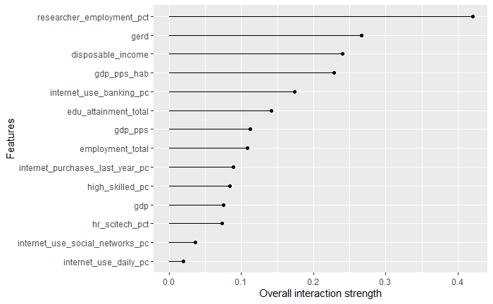

```r
#This code takes several minutes to run if uncommented.
run_in_function <- function() {
  interact <- Interaction$new(predictor_var_select)
  plot(interact) #causes knitr issues, something is wrong with the plot, maybe the size, I saved it and print int from file.

}
#run_in_function()
#I saved the result here:
knitr::include_graphics('images_graphs/percapita_interactions_0416.png')
```

## count per capita - with eurobarometer

[output not shown]

Educational attainment, disposable income may be relevant for the whole population, beyond just researchers.

```r
#count per capita
cpc_predictor_var_select = Predictor$new(
  cpc_var_select.rf,
  data = dplyr::select ( cpc_var_select_df , -geo, - count_per_capita),
  y = as.numeric(cpc_var_select_df$count_per_capita))

cpc_imp <- FeatureImp$new(cpc_predictor_var_select, loss = "mae", n.repetitions = 100)
plot(cpc_imp)
```

## Count per researcher - with eurobarometer

Here we model the per researcher download counts as dependent variables.

[output not shown]

## Linear Regression with EUROBAROMETER

Since the random forest indicated that the EUROBAROMETER variables might be relevant, we tried to enrich our earlier, simplest models with them.

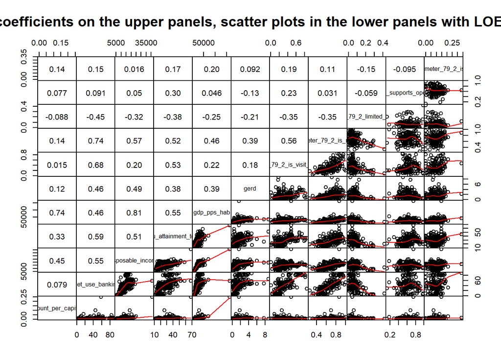

```r
percapita_qplm3_1 <- glm (count_per_million ~
                          log(gdp_pps) +
                          researcher_employment_pct +
                          internet_use_banking_pc+
                        erobarometer_79_2_is_visit_public_library,
                        data = eurostat_eurobarometer_complete_data,
                        family = quasipoisson)


percapita_qplm3_2 <- glm (count_per_million ~
                          log(gdp_pps) +
                          researcher_employment_pct +
                          internet_use_banking_pc+
                                         erobarometer_79_2_is_read_book,
                        data = eurostat_eurobarometer_complete_data,
                        family = quasipoisson)

percapita_qplm3_3 <- glm (count_per_million ~
                          log(gdp_pps) +
                          researcher_employment_pct +
                          internet_use_banking_pc+
                                         eurobarometer_79_2_is_student,
                        data = eurostat_eurobarometer_complete_data,
                        family = quasipoisson)

percapita_qplm3_4 <- glm (count_per_million ~
                          log(gdp_pps) +
                          researcher_employment_pct +
                          internet_use_banking_pc+
                                         erobarometer_79_2_limited_library_supply,

                        data = eurostat_eurobarometer_complete_data,
                        family = quasipoisson)

percapita_qplm3_5 <- glm (count_per_million ~
                          log(gdp_pps) +
                          researcher_employment_pct +
                          internet_use_banking_pc+
                                         erobarometer_79_2_supports_open_access_science,
                        data = eurostat_eurobarometer_complete_data,
                        family = quasipoisson)


export_summs(percapita_qplm3_1, percapita_qplm3_2, percapita_qplm3_3, percapita_qplm3_4,percapita_qplm3_5,
             digits=3,
             statistics = c("null.deviance", "deviance")
             )
```

[output not shown]

[output not shown]

|  | Model 1 | Model 2 | Model 3 | Model 4 | Model 5 |
| --- | --- | --- | --- | --- | --- |
| (Intercept) | 6.196 *** | 5.734 *** | 5.996 *** | 6.324 *** | 5.662 *** |
|  | (0.849) | (0.903) | (0.877) | (0.901) | (0.946) |
| log(gdp_pps) | 0.266 ** | 0.248 ** | 0.269 ** | 0.263 ** | 0.279 ** |
|  | (0.082) | (0.086) | (0.085) | (0.084) | (0.084) |
| researcher_employment_pct | 0.678 *** | 0.652 *** | 0.649 *** | 0.664 *** | 0.651 *** |
|  | (0.057) | (0.058) | (0.060) | (0.057) | (0.058) |
| internet_use_banking_pc | -0.003 | -0.013 ** | -0.008 * | -0.009 * | -0.008 * |
|  | (0.004) | (0.005) | (0.003) | (0.004) | (0.003) |
| erobarometer_79_2_is_visit_public_library | -0.900 |  |  |  |  |
|  | (0.544) |  |  |  |  |
| erobarometer_79_2_is_read_book |  | 1.173 |  |  |  |
|  |  | (0.732) |  |  |  |
| eurobarometer_79_2_is_student |  |  | 1.431 |  |  |
|  |  |  | (1.460) |  |  |
| erobarometer_79_2_limited_library_supply |  |  |  | -1.531 |  |
|  |  |  |  | (1.487) |  |
| erobarometer_79_2_supports_open_access_science |  |  |  |  | 0.539 |
|  |  |  |  |  | (0.515) |
| null.deviance | 2553172.101 | 2553172.101 | 2553172.101 | 2553172.101 | 2553172.101 |
| deviance | 1058039.618 | 1058447.425 | 1074162.804 | 1072966.136 | 1072955.584 |
| *** p < 0.001; ** p < 0.01; * p < 0.05. |  |  |  |  |  |

```r
perresearcher_qplm3_1 <- glm (count_per_thousand_researchers ~
                          log(gdp_pps) +
                          researcher_employment_pct +
                          internet_use_banking_pc+
                        erobarometer_79_2_is_visit_public_library,
                        data = eurostat_eurobarometer_complete_data,
                        family = quasipoisson)

summary(perresearcher_qplm3_1)
```

```
##
## Call:
## glm(formula = count_per_thousand_researchers ~ log(gdp_pps) +
##     researcher_employment_pct + internet_use_banking_pc + erobarometer_79_2_is_visit_public_library,
##     family = quasipoisson, data = eurostat_eurobarometer_complete_data)
##
## Deviance Residuals:
##     Min       1Q   Median       3Q      Max
## -84.276  -24.920  -11.238    6.816  221.363
##
## Coefficients:
##                                            Estimate Std. Error t value Pr(>|t|)
## (Intercept)                                7.090654   0.805511   8.803 4.76e-16
## log(gdp_pps)                               0.135173   0.079629   1.698 0.091063
## researcher_employment_pct                 -0.167086   0.144926  -1.153 0.250247
## internet_use_banking_pc                   -0.016385   0.004261  -3.846 0.000159
## erobarometer_79_2_is_visit_public_library  0.138979   0.537682   0.258 0.796289
##
## (Intercept)                               ***
## log(gdp_pps)                              .
## researcher_employment_pct
## internet_use_banking_pc                   ***
## erobarometer_79_2_is_visit_public_library
## ---
## Signif. codes:  0 '***' 0.001 '**' 0.01 '*' 0.05 '.' 0.1 ' ' 1
##
## (Dispersion parameter for quasipoisson family taken to be 2004.342)
##
##     Null deviance: 350304  on 216  degrees of freedom
## Residual deviance: 282840  on 212  degrees of freedom
## AIC: NA
##
## Number of Fisher Scoring iterations: 5
```

```r
rawcount_qplm3_1 <- glm (count ~
                          log(gdp_pps) +
                          researcher_employment_pct +
                          internet_use_banking_pc+
                        erobarometer_79_2_is_visit_public_library,
                        data = eurostat_eurobarometer_complete_data,
                        family = quasipoisson)

rawcount_qplm3_2 <- glm (count ~
                          log(gdp_pps) +
                          researcher_employment_pct +
                          internet_use_banking_pc+
                        erobarometer_79_2_limited_library_supply,
                        data = eurostat_eurobarometer_complete_data,
                        family = quasipoisson)
summary(rawcount_qplm3_2)
```

```
##
## Call:
## glm(formula = count ~ log(gdp_pps) + researcher_employment_pct +
##     internet_use_banking_pc + erobarometer_79_2_limited_library_supply,
##     family = quasipoisson, data = eurostat_eurobarometer_complete_data)
##
## Deviance Residuals:
##     Min       1Q   Median       3Q      Max
## -350.26   -52.32   -22.59    12.41   587.98
##
## Coefficients:
##                                           Estimate Std. Error t value Pr(>|t|)
## (Intercept)                               0.069472   0.744248   0.093    0.926
## log(gdp_pps)                              0.935546   0.063825  14.658  < 2e-16
## researcher_employment_pct                 0.388654   0.053117   7.317 5.16e-12
## internet_use_banking_pc                  -0.013836   0.003216  -4.302 2.58e-05
## erobarometer_79_2_limited_library_supply -0.919495   1.275537  -0.721    0.472
##
## (Intercept)
## log(gdp_pps)                             ***
## researcher_employment_pct                ***
## internet_use_banking_pc                  ***
## erobarometer_79_2_limited_library_supply
## ---
## Signif. codes:  0 '***' 0.001 '**' 0.01 '*' 0.05 '.' 0.1 ' ' 1
##
## (Dispersion parameter for quasipoisson family taken to be 12337.44)
##
##     Null deviance: 6134520  on 216  degrees of freedom
## Residual deviance: 1673143  on 212  degrees of freedom
## AIC: NA
##
## Number of Fisher Scoring iterations: 5
```